# Discrete-probability-calculations

Jiayu Shi

# 1 Introduction

## 1.1 Background

- Bernoulli random variable

A process or experiment that generates a binary outcome (0 or 1; heads or tails; success or failure)  
Successive replications of the process are independent The probability P(outcome = 1) is constant.

- Binomial random variable

The number of successes in a Bernoulli sequence  
Bernoulli properties still apply: independent outcomes, constant probability

- Negative binomial random variable

The number of failures before the $K^{th}$ success in a Bernoulli sequence is a K negative binomial random variable  
Bernoulli properties still apply: independent outcomes, constant probability

## 1.2 There are five questions

1. What is the probability that the Braves win the World Series given that $P_B$ = 0.55?
2. What is the probability that the Braves win the World Series given that $P_B$ = x? This will be a figure (see below) with $P_B$ on the x-axis and P(Braves win World Series) on the y-axis.
3. Suppose one could change the World Series to be best-of-9 or some other best-of-X series. What is the shortest series length so that P(Braves win World Series|$P_B$ = .55) ≥ 0.8
4. What is the shortest series length so that P(Braves win World Series|$P_B$ = x) ≥ 0.8? This will be a figure (see below) with $P_B$ on the x-axis and series length is the y-axis.
5. Calculate P($P_B$ = 0.55|Braves win World Series in 7 games) under the assumption that either $P_B$ = 0.55 or $P_B$ = 0.45. Explain your solution.

# 2 Methods

```r
library(tidyverse)
```

## 2.1 For the first question

- There are three different solutions which can be used to solve the question.
- First, using **Binomial Distribution**. As the rule says, the first team to win 4 out of 7 games wins the championship, if Braves want to win the World Series, they must win the fourth game before Yankees win the fourth game. So I will list all possible senarios to illustrate the probability.

The most ideal senario is that the Braves win 4 straight games, which means Yankees never win one game. The probability is ${3 \choose 3}*P_B^4$.

The less most ideal senario is that Braves win the fifth game, and only lose one game in the first four games. The probability is ${4 \choose 3}*P_B^3*(1-P_B)*P_B = {4 \choose 3}*P_B^4*(1-P_B)$. ${4 \choose 3}$ is the number of the total possible senarios that Braves only lose one game in the first four games. For example, the first four games’ outcome is: “BBBY”, “BBYB”, “BYBB”, or “YBBB”.(B stands for Braves win, and Y stands for Yankees win)

The third senario is that Braves win the sixth game, and lose two games in the first five games. The probability is ${5 \choose 3}*P_B^3*(1-P_B)^2*P_B = {5 \choose 3}*P_B^4*(1-P_B)^2$. ${5 \choose 3}$ is the number of the total possible senarios that Braves win three games in the first five games. For example, the first five games’ outcome may be: “BBBYY”, “BBYBY”, and so on.

The probability that the Braves win the World Series given that $P_B$ = 0.55 is:
$$\sum_{i=0}^{3}{i+3 \choose
3}P_B^4(1-P_B)^i$$

- Second, using **Negative Binomial Distribution**, probability that Braves win the World Series is the sum of probabilities Braves lose 0, 1, 2, 3 times before Braves win the fourth games. The probability is:
  $$\sum_{i=0}^3dnbinom(i,4,P_B) \text{,i means the number of
  losses}$$
- Third, using **Negative Binomial Cumulative Probability**, probability that Braves win the World Series is the sum of probabilities Braves lose 0, 1, 2, 3 times before Braves win the fourth games. The probability is:
  $$pnbinom(3,4,P_B)$$
  I will use the **Negative Binomial Cumulative Probability** function in R to calculate the probability.

```r
pnbinom(3,4,.55)
```

```
## [1] 0.6082878
```

## 2.2 For the second question

- I can replace the specific $P_B$ = 0.55 to $P_B$ = x.

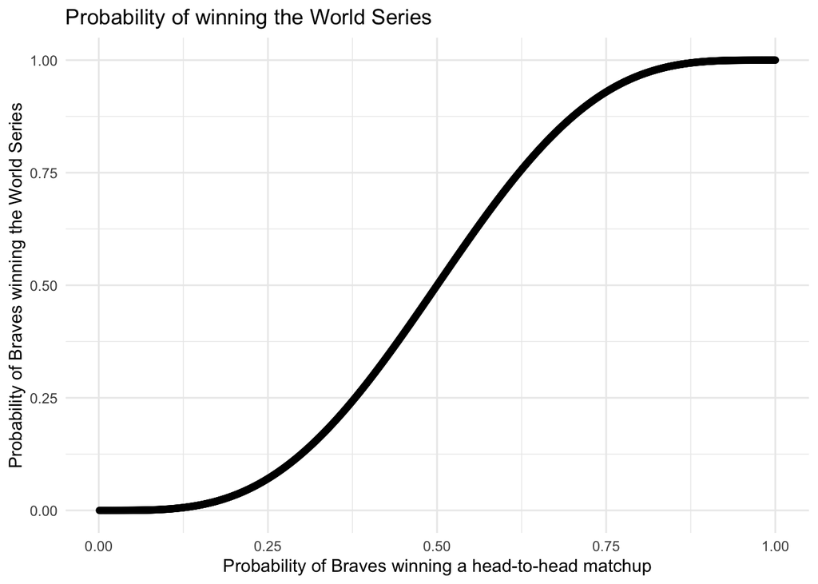

```r
PB = seq(0.001,1,0.001)
ProbabilityWin= pnbinom(3,4,PB)
xy= cbind(PB,ProbabilityWin)
xy= data.frame(xy)
ggplot(xy, aes(PB,ProbabilityWin)) +
  geom_point() +
  labs(
    x="Probability of Braves winning a head-to-head matchup",
    y="Probability of Braves winning the World Series",
    title = "Probability of winning the World Series"
  ) +
  theme_minimal()
```

## 2.3 For the third question

- To figure out what is the shortest series length so that P(Braves win World Series|$P_B$ = .55) ≥ 0.8, I can first make a plot whose x-axis stands for the series length, and whose y-axis stands for the probability of Braves winning the World Series.

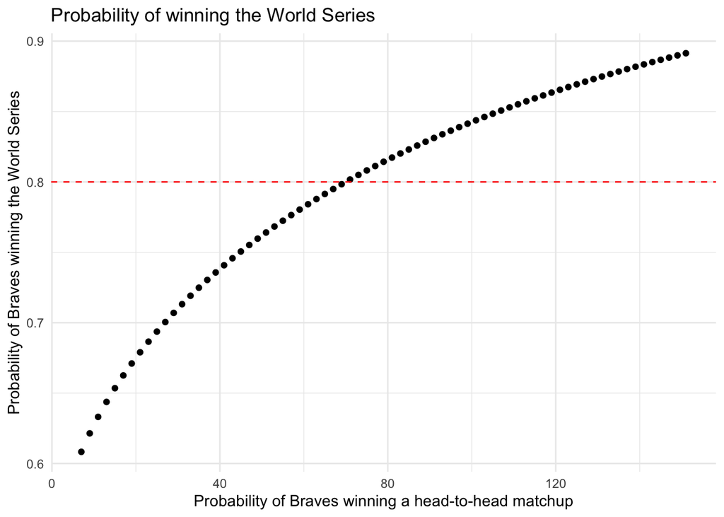

```r
SeriesLength = seq(7,151,2)
numWin = (SeriesLength+1)/2
numLose =  SeriesLength-numWin
ProbabilityWin= pnbinom(numLose,numWin,0.55)
xy= cbind(SeriesLength,ProbabilityWin)
xy= data.frame(xy)

ggplot(xy, aes(SeriesLength,ProbabilityWin)) +
  geom_point() +
  labs(
    x="Probability of Braves winning a head-to-head matchup",
    y="Probability of Braves winning the World Series",
    title = "Probability of winning the World Series"
  ) +
  geom_hline(yintercept=0.8, linetype="dashed", color = "red") +
  theme_minimal()
```

```r
shortestLength <- xy %>%
  filter(ProbabilityWin >= 0.8) %>%
  arrange(SeriesLength) %>%
  head(1)
shortestLength
```

```
##   SeriesLength ProbabilityWin
## 1           71      0.8017017
```

- So the shortest series length is **71**.

## 2.4 For the fourth question

- To figure out what is the shortest series length so that P(Braves win World Series|$P_B$ = x) ≥ 0.8, I use the similar solution as the third question.

```r
PB2 = seq(0.55,1,0.001)
SeriesLength2 = seq(7,100,2)
numWin2 = (SeriesLength2+1)/2
numLose2 =  SeriesLength2-numWin2
shortest = NaN
i=1
for(x in PB2) {
  ProbabilityWin2= pnbinom(numLose2,numWin2,x)
  xy2= cbind(SeriesLength2,ProbabilityWin2)
  xy2= data.frame(xy2)
  shortestLength2 <- xy2 %>%
    filter(ProbabilityWin2 >= 0.8) %>%
    arrange(SeriesLength2) %>%
    head(1)
  shortest[i] = shortestLength2[1,1]
  i = i+1
}
shortest
```

```
##   [1] 71 69 65 63 61 59 57 55 53 51 49 47 47 45 43 43 41 39 39 37 37 35 35 33 33
##  [26] 31 31 31 29 29 27 27 27 25 25 25 25 23 23 23 21 21 21 21 21 19 19 19 19 19
##  [51] 17 17 17 17 17 17 15 15 15 15 15 15 15 13 13 13 13 13 13 13 13 13 13 11 11
##  [76] 11 11 11 11 11 11 11 11 11  9  9  9  9  9  9  9  9  9  9  9  9  9  9  9  9
## [101]  7  7  7  7  7  7  7  7  7  7  7  7  7  7  7  7  7  7  7  7  7  7  7  7  7
## [126]  7  7  7  7  7  7  7  7  7  7  7  7  7  7  7  7  7  7  7  7  7  7  7  7  7
## [151]  7  7  7  7  7  7  7  7  7  7  7  7  7  7  7  7  7  7  7  7  7  7  7  7  7
## [176]  7  7  7  7  7  7  7  7  7  7  7  7  7  7  7  7  7  7  7  7  7  7  7  7  7
## [201]  7  7  7  7  7  7  7  7  7  7  7  7  7  7  7  7  7  7  7  7  7  7  7  7  7
## [226]  7  7  7  7  7  7  7  7  7  7  7  7  7  7  7  7  7  7  7  7  7  7  7  7  7
## [251]  7  7  7  7  7  7  7  7  7  7  7  7  7  7  7  7  7  7  7  7  7  7  7  7  7
## [276]  7  7  7  7  7  7  7  7  7  7  7  7  7  7  7  7  7  7  7  7  7  7  7  7  7
## [301]  7  7  7  7  7  7  7  7  7  7  7  7  7  7  7  7  7  7  7  7  7  7  7  7  7
## [326]  7  7  7  7  7  7  7  7  7  7  7  7  7  7  7  7  7  7  7  7  7  7  7  7  7
## [351]  7  7  7  7  7  7  7  7  7  7  7  7  7  7  7  7  7  7  7  7  7  7  7  7  7
## [376]  7  7  7  7  7  7  7  7  7  7  7  7  7  7  7  7  7  7  7  7  7  7  7  7  7
## [401]  7  7  7  7  7  7  7  7  7  7  7  7  7  7  7  7  7  7  7  7  7  7  7  7  7
## [426]  7  7  7  7  7  7  7  7  7  7  7  7  7  7  7  7  7  7  7  7  7  7  7  7  7
## [451]  7
```

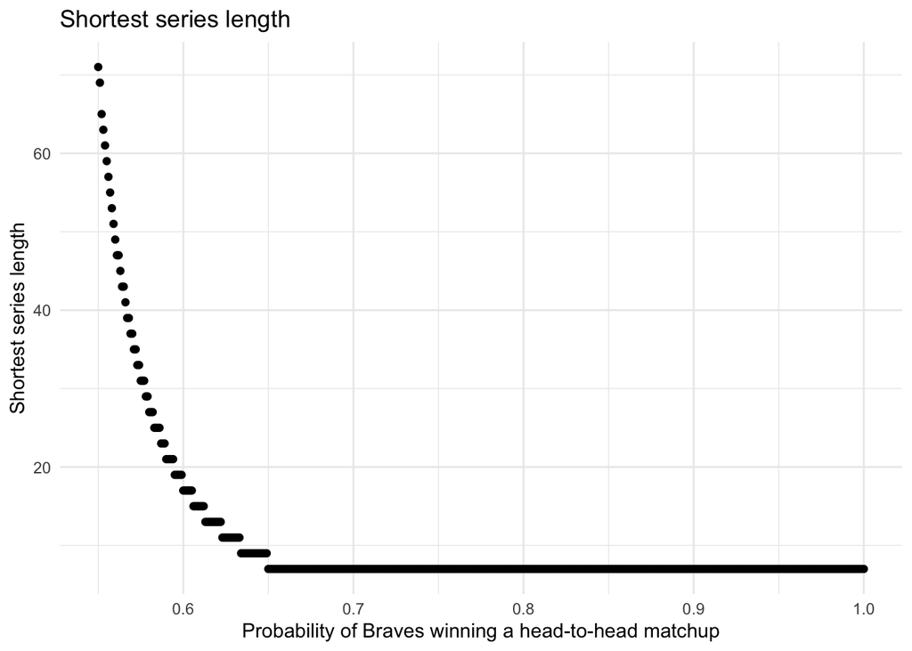

```r
xy3= cbind(PB2,shortest)
xy3= data.frame(xy3)
ggplot(xy3, aes(PB2,shortest)) +
    geom_point() +
    labs(
     x="Probability of Braves winning a head-to-head matchup",
     y="Shortest series length",
     title = "Shortest series length"
   ) +
    theme_minimal()
```

## 2.5 For the fifth question

- To calculate P($P_B$ = 0.55|Braves win World Series in 7 games) under the assumption that either $P_B$ = 0.55 or $P_B$ = 0.45. I need to use Bayesian Rule to tranform the original conditional probability.
  $$P(P_B=0.55 | \text{Braves win World Series in 7
  games})$$
  $$= P(P_B=0.55 ,
  \text{Braves win}) /P(\text{Braves win})$$
  $$=P(\text{Braves win}
  |P_B=0.55)P(P_B=0.55)/(P(\text{Braves win} |P_B=0.55)+P(\text{Braves
  win} |P_B=0.45))$$

```r
PBravesWinConditionPB55 = pnbinom(3,4,0.55)
PBravesWinConditionPB45 = pnbinom(3,4,0.45)
PPB55 = 0.5
answer = PBravesWinConditionPB55*PPB55/(PBravesWinConditionPB55+PBravesWinConditionPB45)
answer
```

```
## [1] 0.3041439
```

The P($P_B$ = 0.55|Braves win World Series in 7 games) under the assumption that either $P_B$ = 0.55 or $P_B$ = 0.45 is **0.3041439**.